# Time Series: A First Course with Bootstrap Starter

# Lesson 9-6: Spectral Means

- We investigate statistics that are weighted sums of the periodogram.

## Proposition 9.6.1.

- The Fourier coefficients of the periodogram are the sample ACVF:
  $$I (\lambda) = \sum_{k = -\infty}^{\infty} \widehat{\gamma} (k) e^{-i
  \lambda k},$$
  and ${ \langle I \rangle }_k = \widehat{\gamma} (k)$.
- So the sample ACVF is positive definite.

## Definition 9.6.2.

A *spectral mean* is a functional of the spectral density $f$, of the form
$$\langle g f \rangle_0 = \frac{1}{2 \pi} \int_{-\pi}^{\pi} g(\lambda)
f(\lambda) \, d\lambda,$$
where $g$ is a real-valued weighting function.

## Remark 9.6.3. Spectral Mean Estimation

A spectral mean can be estimated by substituting the periodogram:
$$\langle g I \rangle_0 = \sum_{|h| < n} { \langle g \rangle }_h
\widehat{\gamma}(h).$$

## Theorem 9.6.6.

Suppose $\{ X_t \}$ is a linear time series with mean $\mu$ and causal moving average representation, with inputs that have variance $\sigma^2$ and kurtosis $\eta$ (fourth moment divided by the square of the second moment). For sufficiently smooth $g$,
$$\sqrt{n} \, \left( \langle g I \rangle_0 - \langle g f \rangle_0 \right)
\Rightarrow \mathcal{N} \left( 0, \langle g (g + g^{\sharp}) f^2
\rangle_0
+ (\eta - 3) { \langle g f \rangle }_0^2 \right),$$
where $g^{\sharp} (\lambda) = g (- \lambda)$.

## Remark 9.6.7. Autocovariance Limiting Variance

- If $g(\lambda ) = \cos (\lambda k)$, then the spectral mean is $\gamma (k)$, and the estimate is $\widehat{\gamma} (k)$.
- The Bartlett Formula (Proposition 9.4.3) follows from Theorem 9.6.6.

## Corollary 9.6.9. Ratio Statistics

Under same assumptions as Theorem 9.6.6, with smooth weighting functions $a$ and $b$,
$$\sqrt{n} \, \left( \frac{ \langle b I \rangle_0 }{ \langle a I \rangle_0
}
- \frac{ \langle b f \rangle_0 }{ \langle a f \rangle_0 } \right)
\Rightarrow \mathcal{N} \left( 0, \frac{ \langle g (g + g^{\sharp}) f^2
\rangle_0 }{ { \langle a f \rangle }_0^2 } \right),$$
where $g = b - a { \langle b f \rangle}_0 / { \langle a f \rangle}_0$.

## Remark 9.6.10. Bartlett’s Formula for the Autocorrelations

- The sample autocorrelation is defined as $\widehat{\rho} (k) = \widehat{\gamma} (k)/ \widehat{\gamma} (0)$.
- Applying Corollary 9.6.9 with $b(\lambda) = \cos (\lambda k)$ and $a \equiv 1$, we find the asymptotic variance for the sample autocorrelation is
  $$\frac{ { \langle f^2 \rangle }_{2k} }{ { \langle f \rangle }_0^2 } + (1
  + 2 { \rho (k) }^2 ) \,
  \frac{ { \langle f^2 \rangle }_{0} }{ { \langle f \rangle }_0^2 } - 4
  \rho (k) \, \frac{ { \langle f^2 \rangle }_{k} }{ { \langle f \rangle
  }_0^2 }.$$
- For white noise, this equals $1$.

## Remark 9.6.12. Autocorrelations of Reduced Population Data

- Consider second differences of U.S. population data.
- We compute the sample autocorrelations, and test the hypothesis of zero serial correlation (i.e., white noise).
- For each lag $k \geq 1$ (treated separately, ignoring multiple testing…) the asymptotic $95 \%$ critical values are $\pm 1.96/\sqrt{n}$.

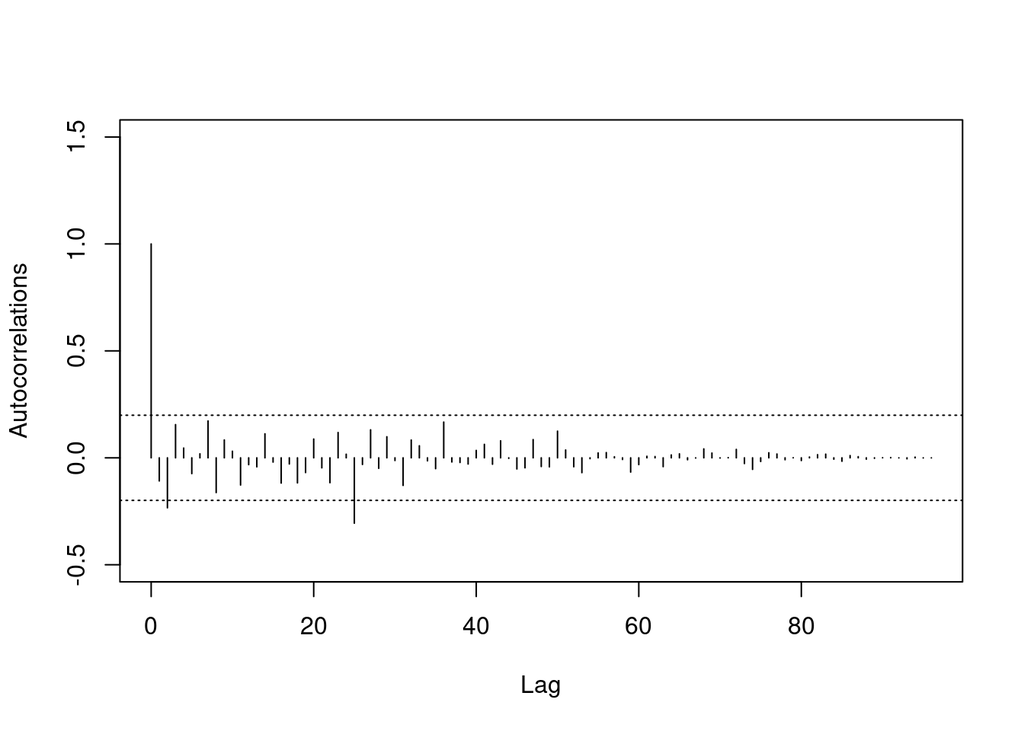

```r
pop <- read.table("USpop.dat")
pop <- ts(pop, start = 1901)
diffdiff.pop <- diff(diff(pop*10e-6))
data <- diffdiff.pop
n <- length(data)
acfs.sample <- NULL
mu.hat <- sum(data)/n
for(k in 0:(n-1))
{
    acf.sample <- sum((data[1:(n-k)]-mu.hat)*(data[(k+1):n]-mu.hat))/n
    acfs.sample <- c(acfs.sample,acf.sample)
}
plot(ts(acfs.sample/acfs.sample[1],start=0),xlab="Lag",ylab="Autocorrelations",ylim=c(-.5,1.5),type="h")
abline(h= 1.96/sqrt(n),lty=3)
abline(h= -1.96/sqrt(n),lty=3)
```